# Twitter US Airline Sentiment

3/13/2021

## Purpose

The purpose of this independent analysis is to analyze how travelers in February 2015 expressed their feelings about US airlines on Twitter.

This data came from the Crowdflower’s Data for Everyone library. However, I reformatted the data a little bit to provide a comprehensive analysis.

## Guiding Questions

- What is the public sentiment expressed toward the US Airlines in 2015?
- How does sentiment show differences for United and American Airlines?

## Mehtod

**Data Source**: tweet created date, tweet location, and tweet text.

**Data Processing**: Wrangle, tokenized, and tidied text

**Data Analysis**: Word Counts,Term Frequency-Inverse Document Frequency, Sentiment Analysis (lexicons: bing and loughran)

## Tweets by Days

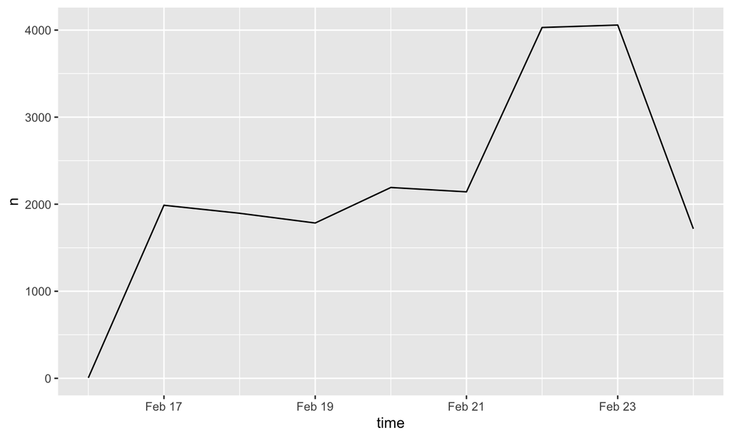

## Frequently Used Words in Tweets

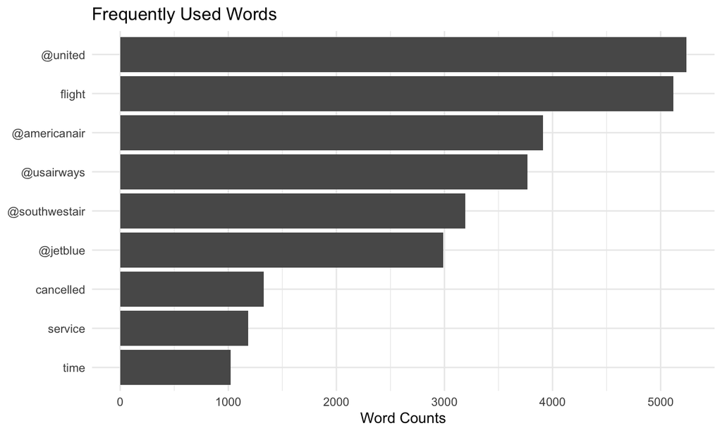

## Sample from Tweets

@VirginAmerica you’re the best!! Whenever I (begrudgingly) use any other airline I’m delayed and Late Flight :(

@VirginAmerica Thanks! Good times there and back! #Vodkatonics the entire flight…

@AmericanAir leaving over 20 minutes Late Flight. No warnings or communication until we were 15 minutes Late Flight. That’s called shitty customer svc

@AmericanAir thx for nothing on getting us out of the country and back to US. Broken plane? Come on. Get another one.

## Sentiment Analysis

## Bing

```
## # A tibble: 2 x 5
## # Groups:   Airline [2]
##   lexicon Airline  negative positive sentiment
##   <chr>   <chr>       <int>    <int>     <int>
## 1 bing    American     4841     2656     -2185
## 2 bing    United       4841     2656     -2185
```

## Loughran

```
## # A tibble: 2 x 9
## # Groups:   Airline [2]
##   lexicon Airline constraining litigious negative positive superfluous
##   <chr>   <chr>          <int>     <int>    <int>    <int>       <int>
## 1 loughr… Americ…           67       100     4063      661           2
## 2 loughr… United            67       100     4063      661           2
## # … with 2 more variables: uncertainty <int>, sentiment <int>
```

## Public Sentiment on Twitter

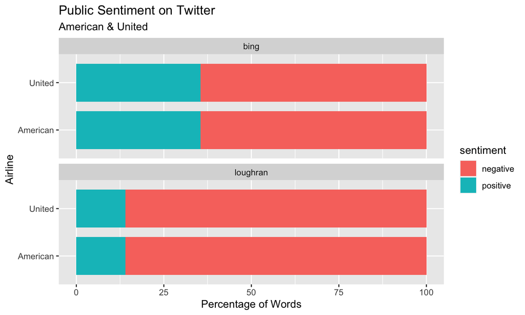